# Moroccan Used Car Price Prediction

EDA · Data Cleaning · Machine Learning

BAHLAOUI Ahmed · ENNAKHLAOUI Aya · LOGRAINE Wiam

## Abstract

This project was developed by students of **AI/Data Science** at **ENSAM RABAT**, under the supervision of **Pr. Dafrallah & Pr. El Yadari**.

We thank them for the valuable insights we gained, and we hope to keep learning from them.

> *“All models are wrong, but some are useful.” - George Box.*

Our pipeline, from start to finish:

| Step | Description |
| --- | --- |
| **EDA** | Understand the data before touching it |
| **Cleaning** | Handle missing values, outliers, encoding |
| **Feature Engineering** | Create and select meaningful signals |
| **Modeling** | Train & compare Ridge, Lasso, Random Forest, XGBoost |
| **Evaluation** | Metrics, visualizations, model comparison |

# Why This Dataset?

> *The Moroccan used car market: large, growing, and opaque.*

## The Moroccan Context

Morocco’s used car market is one of the most active in the Maghreb region, with hundreds of thousands of listings online each year.

**Key problems:**

- No standardized public pricing reference
- Buyers and sellers rely on intuition and negotiation
- Prices vary wildly by brand, city, condition, and origin

**Our goal:** build a machine learning model that can **predict used car prices** based on real listing data — giving both buyers and sellers a data-backed reference point.

> Data Source: [Mendeley Data — Moroccan Used Cars Dataset](https://data.mendeley.com/datasets/vjrbcb2rrt/2)  
> We thank the curators of this dataset.

## Dataset Overview

Our dataset has **~100,000 listings** and **15 columns** — each one a clue:

```python
rows, cols = df.shape
print(f"Dataset: {rows:,} rows × {cols} columns")
```

```
Dataset: 101,896 rows × 15 columns
```

| Column | What it tells us |
| --- | --- |
| `Brand`, `Model` | Which car it is |
| `Year`, `Mileage` | How old / used it is |
| `Price` | **Target variable** — what we predict |
| `Condition`, `Gearbox`, `Fuel` | Car characteristics |
| `Location`, `Origin` | Where it’s from |
| `First Owner`, `Equipment` | Status & extras |
| `Fiscal Power`, `Sector`, `Number of Doors` | Technical details |

# Part 1: Data Quality & Cleaning

> *Before modeling, we must understand and fix the data.*

## Diagnosing Missing Values

The first question any data scientist asks — **what’s missing?**

```python
missing = df.isnull().sum()
percent_missing = (missing.sum() / np.prod(df.shape)) * 100
print(f"About {percent_missing:.2f}% of the data is missing")
print(missing[missing > 0])
```

```
About 4.43% of the data is missing
Brand                  1
Model                  1
Condition           3583
Mileage                1
Fiscal Power         280
Number of Doors    11415
Origin             11975
First Owner        14700
Sector               246
Price              25483
dtype: int64
```

Issues we found:

- **Price** missing in some rows → useless without a target
- **Number of Doors** and **Fiscal Power** → can be inferred
- **Condition** → cannot be inferred reliably
- **Origin, First Owner, Sector** → fill with `"Unknown"`
- **Location** → mixed French/Arabic city names

## Chart 1 — Missing Values by Column

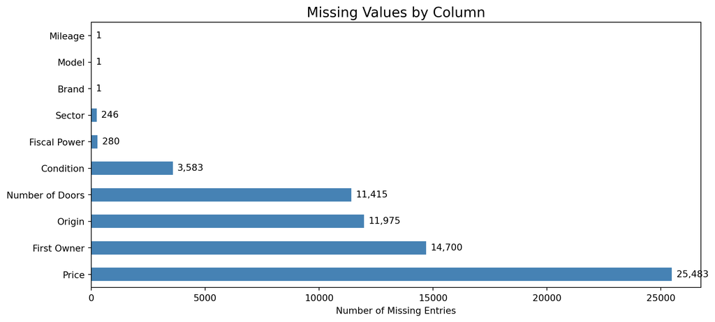

Number of missing entries per column before cleaning

```python
missing_data = df.isnull().sum()
missing_data = missing_data[missing_data > 0].sort_values(ascending=False)

fig, ax = plt.subplots(figsize=(11, 5))
missing_data.plot.barh(ax=ax, color='steelblue')
ax.set_title("Missing Values by Column", fontsize=15)
ax.set_xlabel("Number of Missing Entries")
for p in ax.patches:
    ax.annotate(f"{int(p.get_width()):,}",
                (p.get_width(), p.get_y() + p.get_height() / 2),
                ha='left', va='center', fontsize=10, xytext=(5, 0),
                textcoords='offset points')
plt.tight_layout()
plt.show()
```

## Cleaning Strategy — Per Column

> Each column had a different type of missing data, so each one got a different solution.

| Column | Issue | Strategy | Why |
| --- | --- | --- | --- |
| `Price` | Missing | **Drop rows** | Target variable — useless without it |
| `Number of Doors` | Missing | **Impute** by Brand+Model+Year | Same car model → same door count |
| `Fiscal Power` | Missing | **Impute** by Brand+Model+Year | Same model → same engine power |
| `Condition` | Missing | **Drop rows** | Can’t reliably infer car condition |
| `Origin` | Missing | **Fill** → `"Unknown"` | Better than losing the row |
| `First Owner` | Missing | **Fill** → `"Unknown"` | Could be any owner |
| `Sector` | Missing | **Fill** → `"Unknown"` | Optional metadata |
| `Brand / Model` | Bad row #6714 | **Drop row** | Unrecoverable |
| `Duplicates` | — | **Drop** with `drop_duplicates()` | Data integrity |

## Dropping Rows with Missing Price

> why drop those 25,000 rows instead of just filling in an estimated price?

> The answer is that Price is our target variable — it’s what the model is supposed to learn to predict.

> If we fill it ourselves before training, the model ends up learning from values we invented, which would directly bias the results. Dropping is the only sound choice here.

```python
missing_price_before = df['Price'].isnull().sum()
df = df.dropna(subset=['Price'])
logger.success(f"Dropped {missing_price_before} rows with missing Price")
logger.info(f"Remaining rows: {df.shape[0]:,}")
assert df['Price'].isnull().sum() == 0
```

## Imputing Number of Doors

```python
def fill_doors(df):
    col = 'Number of Doors'
    def group_mode(group_cols):
        return (
            df.dropna(subset=[col])
              .groupby(group_cols)[col]
              .agg(lambda x: x.mode().iloc[0] if not x.mode().empty else np.nan)
        )
    mode_bmy = group_mode(['Brand', 'Model', 'Year'])
    mode_bm  = group_mode(['Brand', 'Model'])
    mode_b   = group_mode(['Brand'])
    overall_mode = df[col].mode().iloc[0]

    def impute(row):
        if pd.notna(row[col]):
            return row[col]
        for key, lookup in [
            ((row['Brand'], row['Model'], row['Year']), mode_bmy),
            ((row['Brand'], row['Model']), mode_bm),
            (row['Brand'], mode_b),
        ]:
            try:
                val = lookup.loc[key]
                if pd.notna(val): return val
            except KeyError:
                pass
        return overall_mode

    df[col] = df.apply(impute, axis=1)
    df[col] = df[col].astype('int64')
    return df

df = fill_doors(df)
print(f"Missing 'Number of Doors' after imputation: {df['Number of Doors'].isnull().sum()}")
```

```
Missing 'Number of Doors' after imputation: 0
```

**Strategy:** Most specific group first (Brand+Model+Year), then fall back gracefully.

## Imputing Fiscal Power

```python
def fill_fiscal_power(df):
    col = 'Fiscal Power'
    def group_mode(group_cols):
        return (
            df.dropna(subset=[col])
              .groupby(group_cols)[col]
              .agg(lambda x: x.mode().iloc[0] if not x.mode().empty else np.nan)
        )
    mode_bmy = group_mode(['Brand', 'Model', 'Year'])
    mode_bm  = group_mode(['Brand', 'Model'])
    mode_b   = group_mode(['Brand'])
    overall_mode = df[col].mode().iloc[0]

    def impute(row):
        if pd.notna(row[col]):
            return row[col]
        for key, lookup in [
            ((row['Brand'], row['Model'], row['Year']), mode_bmy),
            ((row['Brand'], row['Model']), mode_bm),
            (row['Brand'], mode_b),
        ]:
            try:
                val = lookup.loc[key]
                if pd.notna(val): return val
            except KeyError:
                pass
        return overall_mode

    df[col] = df.apply(impute, axis=1)
    return df

df = fill_fiscal_power(df)
print(f"Missing 'Fiscal Power' after imputation: {df['Fiscal Power'].isnull().sum()}")
```

```
Missing 'Fiscal Power' after imputation: 0
```

**Strategy:** Same hierarchical fallback — Brand+Model+Year → Brand+Model → Brand → overall mode.

## Applying All Cleaning Steps

- Drop any row where the car’s condition is missing.
- Fill missing categorical data, like ‘Origin’, with the word ‘Unknown’.
- Remove any duplicate listings or corrupted rows.
- Fix the ‘Year’ column by converting it from messy text into clean numbers, throwing out any unreadable entries and filtered out any row where Brand was numeric.

```python
# Drop rows where condition is missing
df = df.dropna(subset=['Condition'])

# Fill categorical fields with 'Unknown'
df['Origin']      = df['Origin'].fillna('Unknown')
df['First Owner'] = df['First Owner'].fillna('Unknown')
df['Sector']      = df['Sector'].fillna('Unknown')

# Drop unrecoverable row and duplicates
df = df.drop(index=6714, errors='ignore')
df.drop_duplicates(inplace=True)

# Fix Year column type
df['Year'] = pd.to_numeric(df['Year'], errors='coerce')
df = df.dropna(subset=['Year'])
df['Year'] = df['Year'].astype(int)
df = df[~df['Brand'].str.isnumeric()]

print(f"Clean dataset shape: {df.shape}")
```

```
Clean dataset shape: (72239, 15)
```

## Fixing Location — Arabic/French Normalization

> Some listings use Arabic city names, others use French. We standardize to French.

```python
city_mapping = {
    "الدار البيضاء": "Casablanca",
    "الرباط": "Rabat",
    "فاس": "Fès",
    "مراكش": "Marrakech",
    "طنجة": "Tanger",
    "أكادير": "Agadir",
    "وجدة": "Oujda",
    "القنيطرة": "Kénitra",
    "تطوان": "Tétouan",
    "آسفي": "Safi",
    "الجديدة": "El Jadida",
    "العرائش": "Larache",
    "خريبكة": "Khouribga",
    "بني ملال": "Beni Mellal",
    "الناظور": "Nador",
    "العيون": "Laâyoune",
    "الداخلة": "Dakhla",
    "المحمدية": "Mohammedia",
    "مكناس": "Meknès",
    "تمارة": "Temara"
}

df["Location"] = df["Location"].map(city_mapping).fillna(df["Location"])
print(f"Total unique locations after mapping: {df['Location'].nunique()}")
```

```
Total unique locations after mapping: 364
```

## Handling Price Outliers

> We defined a lower and upper bound. Any price outside those bounds was removed.

> IQR is based on the actual distribution of the data ,not just a random cutoff we picked ourselves.

```python
print(f"Before — Min: {df.Price.min():.0f} MAD | Max: {df.Price.max():.0f} MAD")

# Step 1: Kill known fake values
df["Price"] = df["Price"].replace([1, 2, 5, 10], np.nan)

# Step 2: Drop prices below a domain-informed floor
threshold = 10_000
df = df[df["Price"] >= threshold]

# Step 3: IQR method — removes both lower and upper outliers
Q3 = df.Price.quantile(0.75)
Q1 = df.Price.quantile(0.25)
IQR = Q3 - Q1
lower = Q1 - 1.5 * IQR
upper = Q3 + 1.5 * IQR
df = df[(df["Price"] >= lower) & (df["Price"] <= upper)]

print(f"After  — Min: {df.Price.min():.0f} MAD | Max: {df.Price.max():.0f} MAD")
print(f"Mean: {df.Price.mean():.0f} MAD | Median: {df.Price.median():.0f} MAD")
```

```
Before — Min: 1 MAD | Max: 1600000000 MAD
After  — Min: 10000 MAD | Max: 332000 MAD
Mean: 116122 MAD | Median: 104000 MAD
```

## Renaming Columns

```python
new_names_mapping = {'Number of Doors': 'NoD', 'First Owner': 'FO'}
df.rename(columns=new_names_mapping, inplace=True)
```

## The Dataset is Now Clean!

```python
missing_after = df.isnull().sum()
total_missing = missing_after[missing_after > 0]
if total_missing.empty:
    print("Zero missing values remaining!")
    print(f"Final shape: {df.shape[0]:,} rows × {df.shape[1]} columns")
else:
    print(total_missing)
```

```
Zero missing values remaining!
Final shape: 66,935 rows × 15 columns
```

> *The data is clean. Now let’s explore it.*

# Part 2: Exploratory Data Analysis

> *Understanding the data before modeling is not optional — it’s essential.*

## Chart 2 — Price Distribution

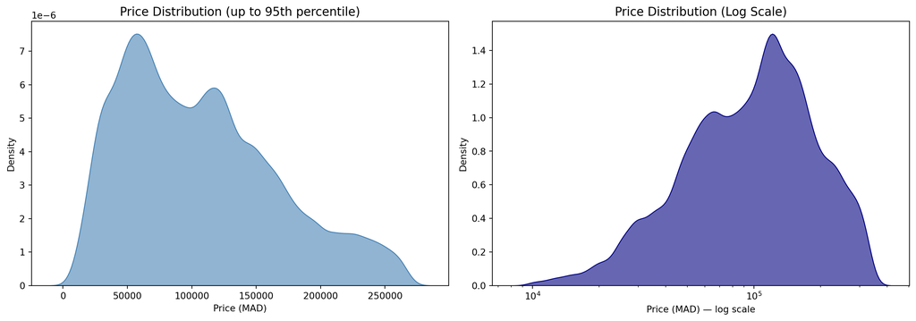

Left: linear scale showing right skew. Right: log scale revealing near-normality.

```python
fig, axes = plt.subplots(1, 2, figsize=(14, 5))

upper = df['Price'].quantile(0.95)
sns.kdeplot(data=df[df['Price'] <= upper], x='Price', fill=True,
            color='steelblue', alpha=0.6, ax=axes[0])
axes[0].set_title('Price Distribution (up to 95th percentile)', fontsize=13)
axes[0].set_xlabel('Price (MAD)')

sns.kdeplot(data=df, x='Price', fill=True, color='navy', alpha=0.6,
            ax=axes[1], log_scale=True)
axes[1].set_title('Price Distribution (Log Scale)', fontsize=13)
axes[1].set_xlabel('Price (MAD) — log scale')

plt.tight_layout()
plt.show()
```

**Key insight:** The distribution is heavily right-skewed. Log-transforming the target makes it near-normal → better for regression models.

## Chart 3 — Price by Year

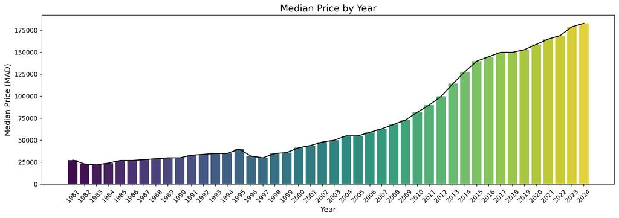

Newer cars consistently command higher prices. Year is one of the strongest predictors.

```python
median_by_year = df.groupby('Year')['Price'].median().reset_index()

fig, ax = plt.subplots(figsize=(14, 5))
sns.barplot(data=median_by_year, x='Year', y='Price', hue='Year',
            palette='viridis', legend=False, ax=ax)
ax.plot(range(len(median_by_year)), median_by_year['Price'],
        color='black', linestyle='-', linewidth=1.5)
ax.set_title('Median Price by Year', fontsize=15)
ax.set_xlabel('Year', fontsize=12)
ax.set_ylabel('Median Price (MAD)', fontsize=12)
ax.tick_params(axis='x', rotation=45)
plt.tight_layout()
plt.show()
```

## Chart 4 — Price by Condition

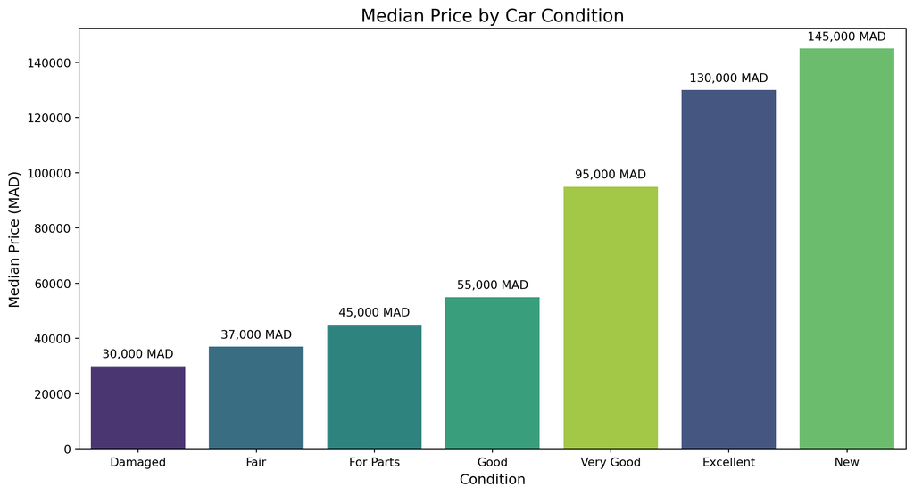

```python
median_price_by_condition = df.groupby('Condition')['Price'].median().reset_index()
condition_order = median_price_by_condition.sort_values('Price')['Condition'].tolist()

fig, ax = plt.subplots(figsize=(11, 6))
sns.barplot(data=median_price_by_condition, x='Condition', y='Price',
            hue='Condition', order=condition_order, legend=False, palette='viridis', ax=ax)
ax.set_title('Median Price by Car Condition', fontsize=15)
ax.set_xlabel('Condition', fontsize=12)
ax.set_ylabel('Median Price (MAD)', fontsize=12)

for p in ax.patches:
    if hasattr(p, 'get_height') and hasattr(p, 'get_x') and hasattr(p, 'get_width'):
        height = float(p.get_height())
        x_center = float(p.get_x()) + float(p.get_width()) / 2.0
        ax.annotate(
            f"{height:,.0f} MAD",
            (x_center, height),
            ha='center', va='bottom', fontsize=10,
            xytext=(0, 5), textcoords='offset points'
        )
plt.tight_layout()
plt.show()
```

**Key insight:** Condition follows a near-perfect price ladder — Fair < Good < Very Good < Excellent, validating it as a strong ordinal predictor.

## EDA Summary — Key Findings

| Factor | Effect on Price |
| --- | --- |
| **Brand** | Porsche, Land Rover, Jaguar at the top |
| **Year** | Newer → More expensive (strong positive trend) |
| **Condition** | Fair < Good < Very Good < Excellent ✅ |
| **Gearbox** | Automatic > Manual (premium linked to newer models) |
| **Fuel** | Diesel dominates (~65% of the market) |
| **First Owner** | Significant premium over multi-owner cars |
| **Origin** | Imported/customs-cleared cars fetch higher prices |
| **Equipment Count** | Positive correlation with price |

# Part 3: Feature Engineering & Selection

> *Raw features rarely speak directly to a model. We need to translate them.*

## Feature Engineering Steps

```python
# Binary encode First Owner
FO_mapping = {"Yes": 1, "No": 0, "Unknown": 0}
df['FO'] = df['FO'].map(FO_mapping)

# Ordinal encode Condition on a 0–1 normalized scale
condition_order = ['For Parts', 'Damaged', 'Fair', 'Good', 'Very Good', 'Excellent', 'New']
condition_map = {cond: i / (len(condition_order) - 1) for i, cond in enumerate(condition_order)}
df['condition_numeric'] = df['Condition'].map(condition_map)

# Count equipment features per listing
df['num_features'] = df['Equipment'].fillna('').apply(
    lambda s: len([x for x in s.split(',') if x.strip() != ''])
)

# Convert mileage range strings → numeric mean value
def mileage_to_mean(mileage_str):
    try:
        if pd.isna(mileage_str): return None
        mileage_str = mileage_str.replace(" ", "").lower()
        if "plusde" in mileage_str:
            return int(re.findall(r"\d+", mileage_str)[0])
        elif "-" in mileage_str:
            low, high = mileage_str.split("-")
            return (int(low) + int(high)) / 2
        return int(mileage_str)
    except:
        return None

df["Mileage_mean"] = df["Mileage"].apply(mileage_to_mean)
df = df[df["Mileage_mean"] < 400_000]

# Extract numeric fiscal power value
df["Fiscal Power"] = df["Fiscal Power"].astype(str).str.extract(r"(\d+)\s*CV").astype(float)

# Log-transform skewed columns
df['Price_log']   = np.log1p(df['Price'])
df['Mileage_log'] = np.log1p(df['Mileage_mean'])

# Car age is more intuitive than raw year for the model
df['Age'] = 2025 - df['Year']

# Interaction term: an old + high-mileage car is much worse than either alone
df['Age_x_Mileage'] = df['Age'] * df['Mileage_log']
```

## Chart 4 — Correlation Matrix

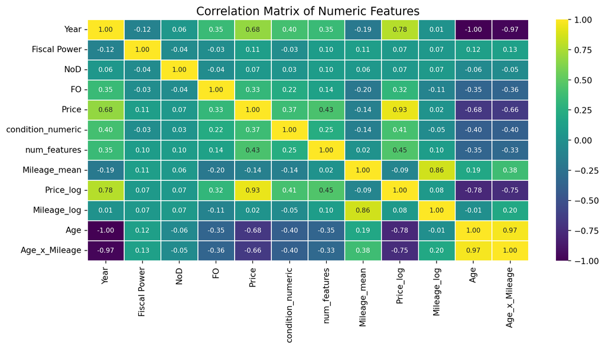

```python
numeric = df.select_dtypes(include=[np.number])
corr_matrix = numeric.corr()

plt.figure(figsize=(11, 6))
sns.heatmap(corr_matrix, cmap='viridis', center=0, annot=True, fmt=".2f",
            linewidths=0.5, annot_kws={"size": 8})
plt.title('Correlation Matrix of Numeric Features', fontsize=14)
plt.tight_layout()
plt.show()
```

## Feature Selection & Encoding Strategy

**Final features selected:**

| Feature | Type | Encoding |
| --- | --- | --- |
| `Age` | Numeric (derived) | StandardScaler |
| `Fiscal Power` | Numeric | StandardScaler |
| `Mileage_log` | Numeric (log) | StandardScaler |
| `Age_x_Mileage` | Numeric (interaction) | StandardScaler |
| `num_features` | Numeric | StandardScaler |
| `condition_numeric` | Ordinal (0–1 normalized) | StandardScaler |
| `FO` | Binary | StandardScaler |
| `Gearbox`, `Fuel`, `Origin` | Categorical | One-Hot Encoding |
| `Brand`, `Model` | High-cardinality | Target Encoding |

**Dropped:** `Year` (→ `Age`), `Mileage_mean` (→ `Mileage_log`), `Location`, `Sector`, `NoD`, `Equipment` (raw), `Condition` (raw)

# Part 4: Preprocessing Pipeline

## Building the Preprocessing Pipeline

```python
from sklearn.model_selection import train_test_split
from sklearn.compose import ColumnTransformer
from sklearn.preprocessing import OneHotEncoder, StandardScaler, TargetEncoder
from sklearn.pipeline import Pipeline
from sklearn.base import clone

# Drop raw/redundant columns
drop_cols = ['Price', 'Price_log', 'Condition', 'Location', 'Sector', 'NoD',
             'Year', 'Mileage', 'Mileage_mean', 'Equipment']
X = df.drop(columns=drop_cols, errors='ignore')
y = df['Price_log']

# 80/20 train-test split — BEFORE any fitting
X_train, X_test, y_train, y_test = train_test_split(
    X, y, test_size=0.2, random_state=42
)

# Column groups
numeric_cols    = ['Age', 'Fiscal Power', 'Mileage_log',
                   'num_features', 'condition_numeric', 'Age_x_Mileage', 'FO']
ohe_cols        = ['Gearbox', 'Fuel', 'Origin']
target_enc_cols = ['Brand', 'Model']

preprocessor = ColumnTransformer(transformers=[
    ('num',    StandardScaler(),                                     numeric_cols),
    ('ohe',    OneHotEncoder(drop='first', handle_unknown='ignore'), ohe_cols),
    ('target', TargetEncoder(target_type='continuous'),              target_enc_cols),
])

print(f"Train size: {X_train.shape[0]:,} | Test size: {X_test.shape[0]:,}")
print(f"Features going in: {X.shape[1]} columns")
```

```
Train size: 52,247 | Test size: 13,062
Features going in: 12 columns
```

**Key choices:**

# Part 5: Model Selection

> *Why these four models? Coverage across the linear/non-linear spectrum.*

## Model Selection Rationale

| Model | Type | Why we chose it |
| --- | --- | --- |
| **Ridge** | Linear + L2 regularization | Handles multicollinearity; interpretable coefficients |
| **Lasso** | Linear + L1 regularization | Implicit feature selection; sparse coefficients |
| **Random Forest** | Ensemble (bagging) | Non-linear, robust, built-in feature importance |
| **XGBoost** | Ensemble (boosting) | State-of-the-art on tabular data; regularization built-in |

**Evaluation metrics:** R², RMSE, MAE on the **test set** (predictions inverse log-transformed to MAD).

## Why Ridge and Lasso?

Ridge and Lasso are **regularized linear regression** models — they minimize the same squared-error loss but add different penalty terms:

- **Ridge (L2):** Shrinks coefficients toward zero — useful when features are correlated (e.g., Year ↔︎ Mileage). Keeps all features.

$$J(\beta)=\sum_{i=1}^n\left(y_i-\sum_{j=0}^p \beta_j x_{i j}\right)^2+\lambda \sum_{j=1}^p \beta_j^2$$
- $\lambda$ (Lambda): The tuning parameter that controls the strength of the penalty.

- $\sum \beta_j^2$: The L2 norm (squared Euclidean norm).
- **Lasso (L1):** Can set coefficients to exactly zero — acts as a built-in feature selector. Useful to understand which features the model ignores.

$$J(\beta)=\sum_{i=1}^n\left(y_i-\sum_{j=0}^p \beta_j x_{i j}\right)^2+\lambda \sum_{j=1}^p\left|\beta_j\right|$$

- $\lambda$ (Lambda): The tuning parameter.
- $\sum |\beta_j|$: The L1 norm (Manhattan norm).

Both serve as **interpretable baselines** to compare against more complex non-linear models.

## Why Random Forest?

Random Forest is a **bagging ensemble** of decision trees:

- Each tree is trained on a **random subset** of rows and features
- Averaging their predictions reduces variance (overfitting)
- Naturally captures **non-linear relationships** (e.g., Year × Brand interactions)
- Provides **built-in feature importance** via mean impurity decrease
- **Robust to outliers** and doesn’t require feature scaling

A strong baseline for tabular data before trying boosting.

## Why XGBoost?

XGBoost is a **gradient boosting** algorithm:

- Trees are built **sequentially** — each one corrects the errors of the previous
- Built-in **L1/L2 regularization** prevents overfitting
- Handles **mixed feature types** natively
- Supports **GPU acceleration** (trained on Google T4 GPU)
- Consistently achieves **state-of-the-art results** on structured/tabular data
- Hyperparameters tuned via **RandomizedSearchCV** with cross-validation

# Part 6: Training & Results

## XGBoost — Optimized Parameters

Parameters were obtained via `RandomizedSearchCV` with 5-fold cross-validation (run on Google Colab T4 GPU).

```python
from sklearn.linear_model import Ridge, Lasso, LinearRegression
from sklearn.ensemble import RandomForestRegressor
from sklearn.metrics import mean_absolute_error, mean_squared_error, r2_score
from sklearn.base import clone
from xgboost import XGBRegressor
import xgboost as xgb

DEVICE = 'cpu'  # change to 'cuda' if running on GPU

def calculate_metrics(y_true, y_pred, name="Model"):
    mae  = mean_absolute_error(y_true, y_pred)
    rmse = np.sqrt(mean_squared_error(y_true, y_pred))
    r2   = r2_score(y_true, y_pred)
    mape = np.mean(np.abs((y_true - y_pred) / y_true)) * 100
    print(f"=== {name} ===")
    print(f"MAE:  {mae:,.0f} MAD  |  RMSE: {rmse:,.0f} MAD  |  R²: {r2:.4f}  |  MAPE: {mape:.2f}%")
    return {"R²": round(r2,4), "MAE": round(mae), "RMSE": round(rmse), "MAPE": round(mape,2)}

# Tuned XGBoost parameters (from RandomizedSearchCV)
optimized_params = {
    'n_estimators':    500,
    'max_depth':       6,
    'learning_rate':   0.05,
    'subsample':       0.7,
    'colsample_bytree': 0.7,
    'reg_lambda':      5,
    'reg_alpha':       0,
    'device':          DEVICE,
    'random_state':    42,
}

xgb_model = XGBRegressor(**optimized_params)

pipeline = Pipeline([
    ('preprocessor', preprocessor),
    ('model', xgb_model)
])

pipeline.fit(X_train, y_train)
final_xgb_model = pipeline.named_steps['model']

y_pred_log = pipeline.predict(X_test)
y_pred_xgb = np.expm1(y_pred_log)
y_true     = np.expm1(y_test)
xgb_metrics = calculate_metrics(y_true, y_pred_xgb, "XGBoost")
```

```
=== XGBoost ===
MAE:  14,124 MAD  |  RMSE: 22,787 MAD  |  R²: 0.8980  |  MAPE: 16.98%
```

## RandomizedSearchCV — Hyperparameter Tuning

> Run on Google Colab T4 GPU. Results used to set `optimized_params` above.

```python
param_dist = {
    'model__n_estimators':  [200, 300, 500],
    'model__max_depth':     [3, 4, 5, 6],
    'model__learning_rate': [0.01, 0.05, 0.1],
    'model__subsample':     [0.7, 0.8, 1.0],
}

search_pipeline = Pipeline([
    ('preprocessor', clone(preprocessor)),
    ('model', XGBRegressor(random_state=42, device='cuda',
                           tree_method='hist', nthread=1))
])

search = RandomizedSearchCV(
    search_pipeline, param_dist,
    n_iter=20, cv=5, scoring='r2',
    random_state=42, n_jobs=1
)
search.fit(X_train, y_train)
print("Best params:", search.best_params_)
print(f"Best CV R²: {search.best_score_:.4f}")
```

[output not shown]

**Same approach applied for Random Forest** with its own param grid (`max_depth`, `max_features`, `min_samples_leaf`, `bootstrap`).

## All 5 Models — Comparison

```python
optimized_params_rf = {
    'n_estimators':     300,
    'max_depth':        20,
    'min_samples_split': 2,
    'min_samples_leaf':  1,
    'max_features':     'log2',
    'bootstrap':        False,
    'random_state':     42,
    'n_jobs':           -1,
}

models = {
    "Linear Regression": LinearRegression(),
    "Ridge":             Ridge(alpha=0.1),
    "Lasso":             Lasso(alpha=0.1, max_iter=10_000),
    "Random Forest":     RandomForestRegressor(**optimized_params_rf),
    "XGBoost":           XGBRegressor(**{**optimized_params,
                                         "objective": "reg:squarederror"}),
}

results = {}
for name, model in models.items():
    pipe = Pipeline([("preprocessor", clone(preprocessor)), ("model", model)])
    pipe.fit(X_train, y_train)
    preds = np.expm1(pipe.predict(X_test))
    true  = np.expm1(y_test)
    results[name] = calculate_metrics(true, preds, name)
```

```
=== Linear Regression ===
MAE:  20,511 MAD  |  RMSE: 31,695 MAD  |  R²: 0.8027  |  MAPE: 22.55%
=== Ridge ===
MAE:  20,506 MAD  |  RMSE: 31,687 MAD  |  R²: 0.8028  |  MAPE: 22.55%
=== Lasso ===
MAE:  31,531 MAD  |  RMSE: 47,674 MAD  |  R²: 0.5537  |  MAPE: 32.47%
=== Random Forest ===
MAE:  12,228 MAD  |  RMSE: 21,273 MAD  |  R²: 0.9111  |  MAPE: 15.01%
=== XGBoost ===
MAE:  14,206 MAD  |  RMSE: 22,858 MAD  |  R²: 0.8974  |  MAPE: 16.83%
```

## Model Comparison — Metrics Table

```python
results_df = pd.DataFrame(results).T
results_df.index.name = "Model"
print(results_df.to_string())
```

```
                       R²      MAE     RMSE   MAPE
Model
Linear Regression  0.8027  20511.0  31695.0  22.55
Ridge              0.8028  20506.0  31687.0  22.55
Lasso              0.5537  31531.0  47674.0  32.47
Random Forest      0.9111  12228.0  21273.0  15.01
XGBoost            0.8974  14206.0  22858.0  16.83
```

**🏆 Random Forest wins** on all metrics. But what does R² actually mean here?

> **Reading R² in plain language:** R² measures the fraction of price variation our model explains on unseen listings.
> - **Random Forest R² = 0.9111** → the model explains **91%** of why one car costs more than another
> - **XGBoost R² = 0.8974** → explains **~90%** of price variation
> - **Ridge/Linear R² ≈ 0.80** → explains only **80%** — the non-linear gap costs us ~10 points
> - **Lasso R² = 0.5537** → only **55%** explained — over-regularization collapsed too many features

> The remaining ~9% (for our best model) is **irreducible noise**: two identical listings can differ by 20,000+ MAD due to negotiation, undisclosed history, or seller behavior — things no feature can capture.

## Chart 5 — Model Comparison (MAE & RMSE)

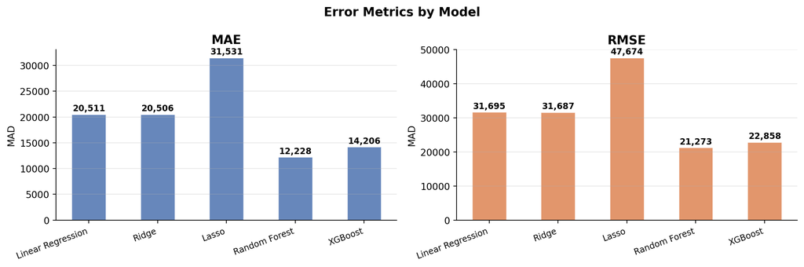

Error metrics — lower is better. Random Forest achieves the lowest MAE and RMSE.

```python
models_list = list(results.keys())
x = np.arange(len(models_list))

fig, axes = plt.subplots(1, 2, figsize=(12, 4))

for ax, metric, color in zip(axes, ["MAE", "RMSE"], ["#4C72B0", "#DD8452"]):
    values = [results[m][metric] for m in models_list]
    bars = ax.bar(x, values, width=0.5, color=color, alpha=0.85, edgecolor="white")
    for bar, val in zip(bars, values):
        ax.text(bar.get_x() + bar.get_width() / 2,
                bar.get_height() + max(values) * 0.01,
                f"{val:,.0f}", ha="center", va="bottom", fontsize=9, fontweight="bold")
    ax.set_title(metric, fontsize=13, fontweight="bold")
    ax.set_xticks(x)
    ax.set_xticklabels(models_list, rotation=20, ha="right", fontsize=9)
    ax.set_ylabel("MAD")
    ax.grid(axis="y", alpha=0.3)
    ax.spines[["top", "right"]].set_visible(False)

plt.suptitle("Error Metrics by Model", fontsize=13, fontweight="bold")
plt.tight_layout()
plt.show()
```

## Chart 5 (cont.) — MAPE & R²

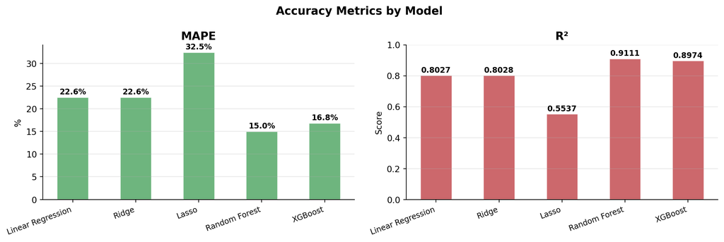

R² closer to 1 is better; MAPE lower is better. Random forest wins on both.

```python
fig, axes = plt.subplots(1, 2, figsize=(12, 4))

for ax, metric, color in zip(axes, ["MAPE", "R²"], ["#55A868", "#C44E52"]):
    values = [results[m][metric] for m in models_list]
    bars = ax.bar(x, values, width=0.5, color=color, alpha=0.85, edgecolor="white")
    for bar, val in zip(bars, values):
        label = f"{val:.1f}%" if metric == "MAPE" else f"{val:.4f}"
        ax.text(bar.get_x() + bar.get_width() / 2,
                bar.get_height() + max(values) * 0.01,
                label, ha="center", va="bottom", fontsize=9, fontweight="bold")
    ax.set_title(metric, fontsize=13, fontweight="bold")
    ax.set_xticks(x)
    ax.set_xticklabels(models_list, rotation=20, ha="right", fontsize=9)
    ax.set_ylabel("%" if metric == "MAPE" else "Score")
    if metric == "R²": ax.set_ylim(0, 1)
    ax.grid(axis="y", alpha=0.3)
    ax.spines[["top", "right"]].set_visible(False)

plt.suptitle("Accuracy Metrics by Model", fontsize=13, fontweight="bold")
plt.tight_layout()
plt.show()
```

## XGBoost — Feature Importance

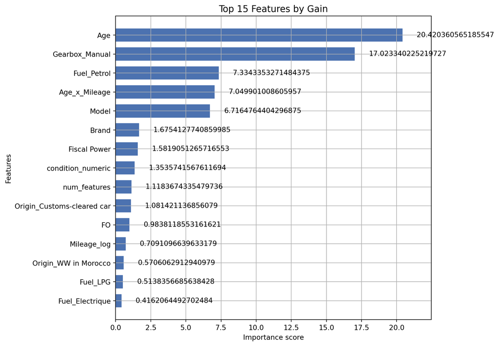

```python
ohe_feature_names = (pipeline.named_steps['preprocessor']
                              .named_transformers_['ohe']
                              .get_feature_names_out(ohe_cols).tolist())
all_features = numeric_cols + ohe_feature_names + target_enc_cols

fig, ax = plt.subplots(figsize=(10, 7))
xgb.plot_importance(final_xgb_model, ax=ax, importance_type='gain',
                    max_num_features=15, height=0.7, color='#4C72B0')

ticks  = ax.get_yticklabels()
labels = [all_features[int(t.get_text()[1:])]
          if t.get_text().startswith('f') else t.get_text()
          for t in ticks]
ax.set_yticklabels(labels)
ax.set_title('Top 15 Features by Gain', fontsize=13)
plt.tight_layout()
plt.show()
```

> **Gain** measures the improvement in accuracy each feature brings to the trees — more meaningful than split frequency (`weight`).

## XGBoost — Top 15 Feature Splits by Frequency

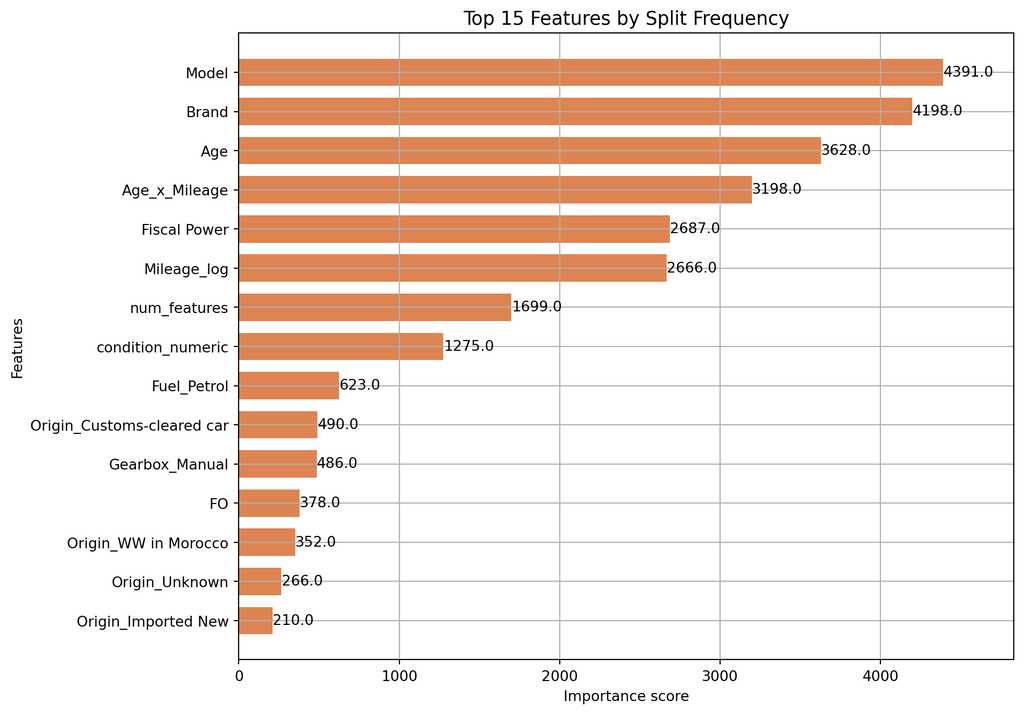

Top 15 features by split frequency (weight). How often each feature is used to split a node across all trees.

```python
fig, ax = plt.subplots(figsize=(10, 7))
xgb.plot_importance(final_xgb_model, ax=ax, importance_type='weight',
                    max_num_features=15, height=0.7, color='#DD8452')

ticks  = ax.get_yticklabels()
labels = [all_features[int(t.get_text()[1:])]\
          if t.get_text().startswith('f') else t.get_text()
          for t in ticks]
ax.set_yticklabels(labels)
ax.set_title('Top 15 Features by Split Frequency', fontsize=13)
plt.tight_layout()
plt.show()
```

> **Split Frequency (weight)** counts how many times a feature is used across all tree splits. High-frequency features are queried often but not necessarily the most impactful — compare with **Gain** above.

# Part 7: Challenges & Lessons Learned

## Challenges Encountered

**1. Data Quality was the biggest bottleneck**

- Mixed Arabic/French location names
- Mileage stored as range strings (`"50000 - 100000 km"`)
- Fiscal Power as strings (`"7 CV"`)
- Price stored with currency symbols and commas

**2. Encoding strategy differs by model family**

- Ridge/Lasso: require scaled numerics + OHE
- XGBoost/RF: don’t need scaling, but still benefit from target encoding on high-cardinality features

**3. High-cardinality features (Brand, Model)**

- Over 60 brands, hundreds of models
- Simple OHE would create thousands of dummy columns → Target Encoding was the right call

**4. Log-transforming the target**

- Raw price is right-skewed → log(price) is near-normal
- Required careful inverse transformation when computing metrics

## Lessons Learned

> *Feature engineering mattered more than model tuning.*

The time spent carefully handling `Mileage`, `Fiscal Power`, and encoding `Brand/Model` correctly contributed more to our final R² than tuning hyperparameters.

| Lesson | Takeaway |
| --- | --- |
| Data cleaning is 60% of the work | Never rush it |
| Log-transform skewed targets | Helps linear models significantly |
| Target Encoding > OHE for high cardinality | Avoids feature explosion |
| Baseline models first | Ridge/Lasso showed us how far non-linearity helps |
| GPU acceleration | Reduced XGBoost training from minutes to seconds |

## Links & Resources

- **Dataset:** [Mendeley Data — Moroccan Used Cars](https://data.mendeley.com/datasets/vjrbcb2rrt/2)
- **Code:** Available on GitHub

# Thank You!

**BAHLAOUI Ahmed · ENNAKHLAOUI Aya · LOGRAINE Wiam**

**ENSAM RABAT — INDIA/SD · 2025/2026**

*Supervised by Pr. Dafrallah & Pr. El Yadari*

> Questions?